# ICE Arrests Nationwide: Geographic Distribution

Post-inauguration arrests from the DDP FOIA dataset

Published

November 19, 2026

Notes for next improvements: 1. The county-level data excludes a lot of towns, Louisiana’s parishes, and many metropolitan areas that don’t follow the “NAME COUNTY” pattern. (We should examine the share of arrests in each state that make each of the patterns.) 2. We could create an interactive line graph with all of the state arrest rates.

Counts and tables below cover arrests on or after **January 20, 2025**. **564,379** arrests · **98.8%** have a state recorded. Both maps offer switchable layers: the post-inauguration period (default) and all data. The monthly trend chart shows the full dataset for context.

## State Bubble Map

Circle **area** is proportional to the number of arrests. Circle **color** shows arrests per 1,000 estimated undocumented immigrants (Pew 2023 estimates), a rough intensity measure independent of state size. Popups include Census 2025 total population and per-capita rates. The layer control (top right) switches between post-inauguration arrests (default) and all data; each layer has its own color scale and legend.

[interactive chart not shown]

**Top 20 states by arrests:**

| State | Arrests | Arrests/1k undoc. | Undoc. pop. (Pew 2023) | Population (2025) | % of arrests |
| --- | --- | --- | --- | --- | --- |
| Texas | 141937 | 69.24 | 2,050,000 | 31,709,821 | 25.4 |
| Florida | 59439 | 37.15 | 1,600,000 | 23,462,518 | 10.7 |
| California | 49164 | 21.85 | 2,250,000 | 39,355,309 | 8.8 |
| Georgia | 21360 | 47.47 | 450,000 | 11,302,748 | 3.8 |
| Arizona | 19818 | 66.06 | 300,000 | 7,623,818 | 3.6 |
| New York | 19233 | 23.31 | 825,000 | 20,002,427 | 3.4 |
| New Jersey | 17442 | 29.07 | 600,000 | 9,548,215 | 3.1 |
| Virginia | 15489 | 47.66 | 325,000 | 8,880,107 | 2.8 |
| Tennessee | 14657 | 77.14 | 190,000 | 7,315,076 | 2.6 |
| Pennsylvania | 12610 | 42.03 | 300,000 | 13,059,432 | 2.3 |
| Alabama | 10698 | 125.86 | 85,000 | 5,193,088 | 1.9 |
| North Carolina | 9829 | 23.13 | 425,000 | 11,197,968 | 1.8 |
| Oklahoma | 9567 | 95.67 | 100,000 | 4,123,288 | 1.7 |
| Massachusetts | 9490 | 23.72 | 400,000 | 7,154,084 | 1.7 |
| Louisiana | 9185 | 83.50 | 110,000 | 4,618,189 | 1.6 |
| Maryland | 8899 | 25.43 | 350,000 | 6,265,347 | 1.6 |
| Indiana | 8345 | 52.16 | 160,000 | 6,973,333 | 1.5 |
| South Carolina | 7859 | 56.14 | 140,000 | 5,570,274 | 1.4 |
| Illinois | 7792 | 14.17 | 550,000 | 12,719,141 | 1.4 |
| Utah | 7531 | 53.79 | 140,000 | 3,538,904 | 1.3 |

## County-Level Choropleth

Counties are attributed with the same `assign_arrest_location()` engine the state reports use: from the arrest city where a Census place–county crosswalk exists (IL, MN, TN), otherwise from `apprehension_site_landmark` (explicit “NAME COUNTY” patterns, airports, general-area codes). Generic county parses are validated against the state’s real county list, so typos and cross-state name collisions are dropped rather than misplotted.

> **Coverage:** 92.5% of post-January 20, 2025 arrests and 87.6% of all-data arrests mapped to a county.

[interactive chart not shown]

> **Note:** Counties with zero arrests shown in light grey may have arrests recorded under non-specific landmarks. Alaska, Hawaii, and Puerto Rico appear on the bubble map (fixed centroids) but are excluded from this choropleth — the `maps` package has no county boundary data for them.

**Top 30 counties by arrests:**

| County | State | N | % |
| --- | --- | --- | --- |
| Dallas | Texas | 19146 | 3.7 |
| Montgomery | Texas | 18236 | 3.5 |
| Webb | Texas | 14371 | 2.8 |
| Bexar | Texas | 12665 | 2.4 |
| Sandiego | California | 11487 | 2.2 |
| Harris | Texas | 11069 | 2.1 |
| Miami-Dade | Florida | 10177 | 2.0 |
| Maricopa | Arizona | 8668 | 1.7 |
| Losangeles | California | 8522 | 1.6 |
| Pinal | Arizona | 7270 | 1.4 |
| Orange | Florida | 6557 | 1.3 |
| Cameron | Texas | 6212 | 1.2 |
| Fulton | Georgia | 6164 | 1.2 |
| Broward | Florida | 6026 | 1.2 |
| Hidalgo | Texas | 5865 | 1.1 |
| Travis | Texas | 5550 | 1.1 |
| Cook | Illinois | 5462 | 1.0 |
| Hillsborough | Florida | 5310 | 1.0 |
| Queens | New York | 5251 | 1.0 |
| Oklahoma | Oklahoma | 5026 | 1.0 |
| Fairfax | Virginia | 4872 | 0.9 |
| Valverde | Texas | 4828 | 0.9 |
| Essex | New Jersey | 4549 | 0.9 |
| Elpaso | Texas | 4526 | 0.9 |
| Lee | Florida | 3983 | 0.8 |
| Clark | Nevada | 3699 | 0.7 |
| Imperial | California | 3579 | 0.7 |
| Doñaana | New Mexico | 3488 | 0.7 |
| Mecklenburg | North Carolina | 3312 | 0.6 |
| Sanbernardino | California | 3245 | 0.6 |

## Monthly Trends by Top State

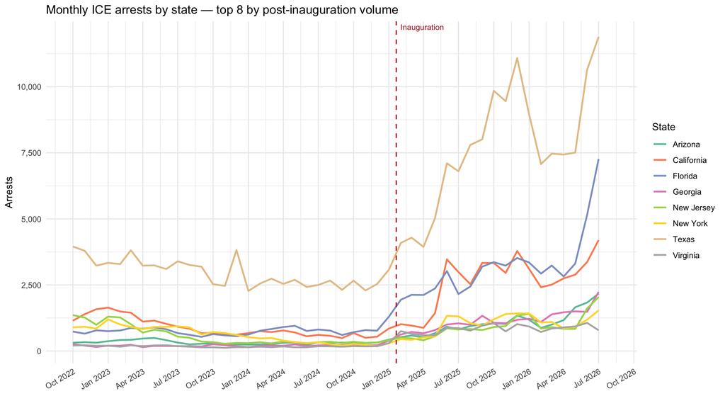

## Arrest Rate Change by State

For each state, compute arrests **per day** in the before and after periods, then take the ratio. Values above 1 mean more arrests per day after inauguration; values below 1 mean fewer. Only states with at least 30 arrests in the before period are included.

**All states and DC — arrest rate change and removal outcomes:**

| Per day (before) | Per day (after) | Ratio | State | Arrests (after) | Arrests/1k undoc. | Undoc. pop. (Pew) | % Removed | % Released | % Pending |
| --- | --- | --- | --- | --- | --- | --- | --- | --- | --- |
| 0.11 | 3.34 | 30.59 | District Of Columbia | 1872 | 53.49 | 35000 | 74.6 | 19.6 | 5.8 |
| 0.82 | 10.49 | 12.8 | New Mexico | 5939 | 98.98 | 60000 | 88.1 | 5 | 6.9 |
| 0.68 | 5.08 | 7.48 | West Virginia | 2856 | 285.6 | 10000 | 78.1 | 11.7 | 10.2 |
| 6.8 | 37.87 | 5.57 | Georgia | 21360 | 47.47 | 450000 | 76 | 10.3 | 13.7 |
| 0.58 | 3.06 | 5.32 | Wyoming | 1725 | 172.5 | 10000 | 70.5 | 17.7 | 11.9 |
| 5.7 | 27.34 | 4.8 | Virginia | 15489 | 47.66 | 325000 | 72.5 | 17.4 | 10 |
| 1.02 | 4.5 | 4.4 | Oregon | 2534 | 21.12 | 120000 | 75.3 | 17.1 | 7.5 |
| 24.44 | 104.57 | 4.28 | Florida | 59439 | 37.15 | 1600000 | 66.2 | 18.3 | 15.5 |
| 5.71 | 22.36 | 3.92 | Pennsylvania | 12610 | 42.03 | 300000 | 66.7 | 19.3 | 14 |
| 2.21 | 8.64 | 3.91 | Nevada | 4871 | 22.14 | 220000 | 66.3 | 22.4 | 11.3 |

[output cut: 41 more lines]

[figure not shown]

## Removal Destinations

`departure_country` records where each person was actually sent. Of **443,629** removals with a recorded destination, **16,161** (3.6%) involved removal to a country other than the person’s citizenship country. The grid below shows nationalities and destinations with at least 500 removals.

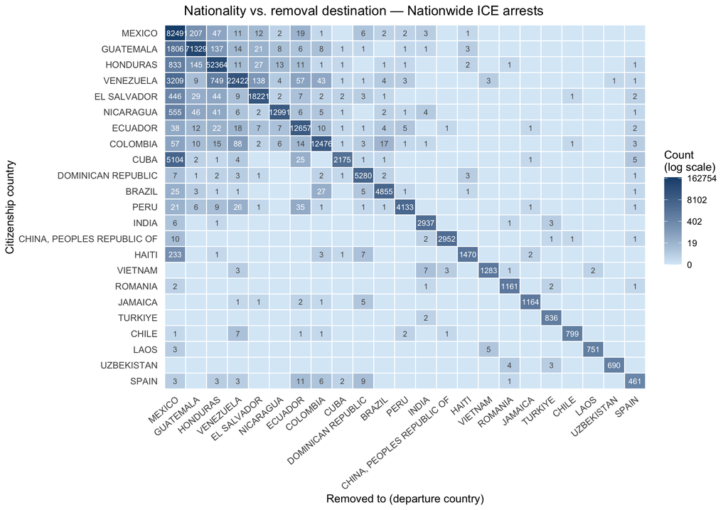

## Data notes

- Source: [Deportation Data Project](https://deportationdata.org), FOIA 2026-ICLI-00005.
- Counts and tables filtered to arrests on or after **January 20, 2025** (564,379 arrests). Both maps also carry an “all data” layer (Oct 2022 – Aug 2026), off by default; each layer has its own color scale. Trend chart shows the full dataset from October 2022 – August 2026.
- `apprehension_state` is missing for 6,515 post-cutoff rows (1.2%); excluded from state and county counts.
- County attribution uses the project’s `assign_arrest_location()` engine: city → county via the Census place crosswalk (IL, MN, TN), otherwise the landmark engine (explicit county names, airports, general-area codes), with generic county parses validated against each state’s real county list.
- Alaska, Hawaii, and Puerto Rico appear on the bubble map via fixed approximate centroids (the `maps` package has no state/county boundary data for them) and are absent from the county choropleth. Pew has no Puerto Rico estimate, so its bubble renders grey.
- **Landmark-to-state assignments:** rows left without a state by the DDP fill and `fill_arrest_states_aor()` were assigned to a state when the landmark had more than 25 arrests and more than 70% of its known-state rows agreed (or the site is unambiguous by name). The table lives in the pipeline as `nationwide_landmark_states()` (R/state-arrests.R), applied inside the `nationwide_arrests_located` target. 6515 post-cutoff rows remain unassigned. The cases, grouped by state with the agreeing share of known-state rows in parentheses:
  - **Colorado:** FRD GENERAL AREA (94%). **South Dakota:** SFD (90%). **Missouri:** STL (89%). **Illinois:** CHI (92%), RII (90%). **Texas:** EPC (81%), ELP (91%), SMITH COUNTY SHERIFFS OFFICE (94%), LIV (85%), and KANSAS CITY DETENTION AND REMOVAL OPERATIONS (94% — note: despite the name, its rows are 94% Texas with an 86% San Antonio AOR). **Virginia:** WAS (76%). **New Mexico:** ABQ (92%). **Washington:** Spokane CAP (95%). **California:** CAP - FCI HERLONG CALIFORNIA (92%), CSP SOLANO (95%). **Pennsylvania:** PIT (89%). **Idaho:** BOISE ICE OFFICE (94%). **Iowa:** CRI (95%). **Oregon:** POO CAP NON-CUSTODIAL ARREST (75%), SHERIDAN FCI (89% — FCI Sheridan, Oregon; Seattle AOR 100%), PORTLAND FUGITIVE OPERATIONS STREET ARREST (89% — Seattle AOR, with arrest cities Portland, Beaverton, and Hillsboro: this is Portland, Oregon, not Maine). **North Dakota:** GRF (78%; Grand Forks). **Nevada:** REN (86%; Reno). **Wyoming:** CITY OF CASPER (93%). **Louisiana:** OAK (90%; Oakdale), JNA (90%; Jennings). **Connecticut:** HAR (74%; Hartford). **Kentucky:** LOU (94%; Louisville). **Georgia:** FOK (84%; Folkston). **Tennessee:** MEM (80%; Memphis). **District of Columbia:** USMS DC SUPERIOR COURT (named for the DC Superior Court; known rows are 23 DC vs. 10 Virginia).
  - Rejected under the rule: KAN GENERAL AREA (Missouri 52% vs. Kansas 48%), JOHNSON COUNTY JAIL (Texas 56% vs. Arkansas 44%), ALTERNATIVES TO DETENTION (52%), WSM, TOD, OOP, WNF, TXA, BOS, FUGITIVE OPERATION, SC INTEROPERABILITY LAFO (all below 70% agreement).
- **Census population** from U.S. Census Bureau, “Annual Estimates of the Resident Population for the United States, Regions, States, District of Columbia and Puerto Rico” (NST-EST2025-POP.xlsx), July 1 2025 estimates.
- **Undocumented population** from Pew Research Center, “Unauthorized immigrants: Characteristics for states” (2023 estimates, released 2025). Estimates are rounded to the nearest 5,000–50,000 depending on state size.
- Arrest intensity (arrests per 1,000 undocumented) uses Pew 2023 undocumented population as denominator; this is the most recent state-level estimate available.